# Introduction to Bulk RNAseq data analysis

QC of raw reads with FastQC - Solutions

### Exercise

1. 1. Check the location of the current directory using the command `pwd`
   2. If the current directory is not `Course_Materials`, then navigate to the **Course_Materials** directory using the `cd` (**c**hange **d**irectory) command:

```bash
cd ~/Course_Materials
```

2. 1. Use `ls` to list the contents of the directory. There should be directory called **fastq**
   2. Use `ls` to list the contents of the **fastq** directory:

```bash
ls fastq
```

> SRR7657883.sra_1.fastq.gz SRR7657883.subset_2M.sra_1.fastq.gz  
> SRR7657883.sra_2.fastq.gz Test_adapter_contamination.gq.gz.  
> SRR7657883.subset_2M.sra_2.fastq.gz

3. Run fastqc on one of the fastq files:

```bash
fastqc fastq/SRR7657883.sra_1.fastq.gz
```

This creates two files in the *fastq* directory. The first is the QC report in html format and the second is a zip file containing the data summary data used to generate the report. > $\Rightarrow$ *SRR7657883.sra_1_fastqc.html*  
> $\Rightarrow$ *SRR7657883.sra_1_fastqc.zip*

4. Open the html report in a browser and see if you can answer these questions:  
   A) What is the read length?

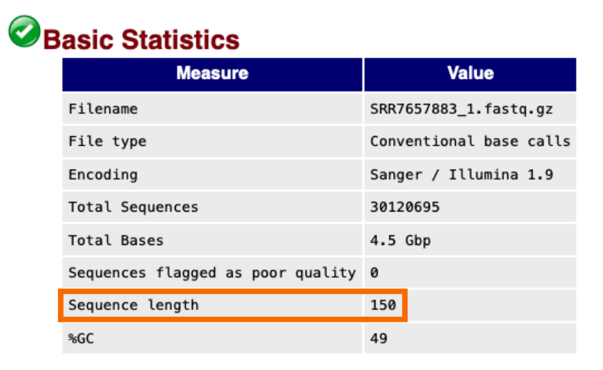

   **150**  
   B) Does the quality score vary through the read length?

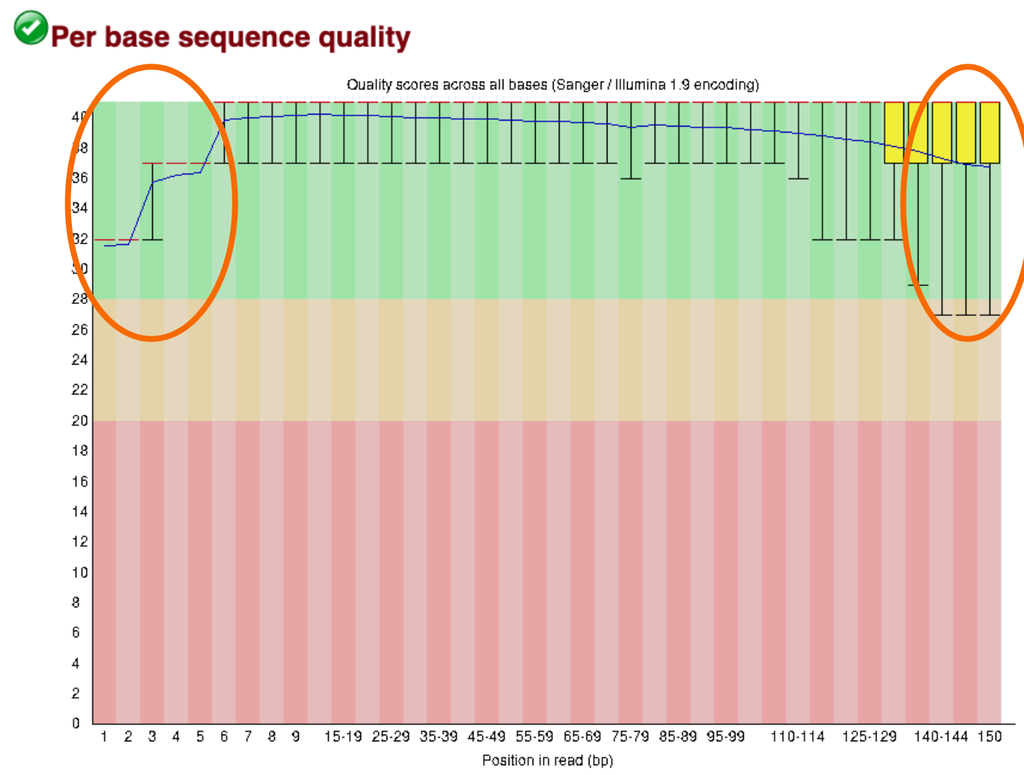

   Yes, the first few bases and the last few bases are typically of lower quality.  
   C) How is the data's quality?  
   Overall, pretty good.